# Unit 04 Lab Agenda

## 5. Models and their parameters

> *Q: Can we discuss more about parameters in KNN, LR, LDA/QDA/RDA and what we should be and should not be tuning?*

### Linear Regression

- penalty: amount of regularization
- mixture: proportion of L1 regularization

```r
linear_reg(penalty = NULL, mixture = NULL) |>
  set_engine("lm")
```

### KNN

- neighbors: number of neighbors to consider
- weight_func (`rectangular`, `triangular`, `epanechnikov`, `biweight`, `triweight`, `cos`, `inv`, `gaussian`, `rank`, `optimal`): the function used to weight distances
- dist_power: for calculating Minkowski distance

```r
nearest_neighbor(neighbors = NULL, weight_func = NULL, dist_power = NULL) |>
  set_engine("kknn") |>
  set_mode("regression") # or set_mode("classification")
```

### Logistic Regression

- penalty: amount of regularization
- mixture: proportion of L1 regularization

```r
logistic_reg(penalty = NULL, mixture = NULL) |>
  set_engine("glm")
```

### discriminant analysis

#### LDA

- penalty: amount of regularization
- regularization_method (`diagonal`, `min_distance`, `shrink_cov`, `shrink_mean`): type of regularized estimation

```r
discrim_linear(penalty = NULL, regularization_method = NULL) |>
  set_engine("MASS")
```

#### QDA

- frac_common_cov
- frac_identity

```r
discrim_regularized(frac_common_cov =  NULL, frac_identity = NULL) |>
  set_engine("klaR")
```

### Naive bayes classifier

- smoothness: relative smoothness of the class boundary
- Laplace: Laplace correction to smoothing low-frequency counts

```r
naive_Bayes(smoothness = NULL, Laplace = NULL) |>
  set_engine("naivebayes")
```

### Random Forest

- mtry: number of predictors at each split
- trees: number of trees in the ensemble
- min_n: required minimum number of data points in a node

```r
rand_forest(mtry = NULL, trees = NULL, min_n = NULL) |>
  set_engine("ranger") |>
  set_mode("classification") # or set_mode("regression")
```

### Neural Networks

- hidden_units: number of units in the hidden model
- penalty: amount of weight decay
- dropout: proportion of model parameters randomly set to zero
- epochs: number of training iterations
- activation (`linear`, `softmax`, etc): type of relationship between the original predictors and the hidden unit layer
- learn_rate: rate at which the boosting algorithm adapts from iteration-to-iteration

```r
mlp(hidden_units = NULL, penalty = NULL, dropout = NULL, epochs = NULL,
    activaation = NULL, learn_rate = NULL) |>
  set_engine("nnet") |>
  set_mode("classification") # or set_mode("regression")
```

## 6. Multinomial regression, ordinal logistic regression

> *Q: When would we use multinomial logistic regression vs. ordinal logistic regression?*

**Ordinal regression**: when the outcome variable is ordered

## 7. Pipeline of selecting the best model and generating test predictions

> *Q: You mentioned before that after training, validation, and selecting the best model, that one optional step is before taking that best model into test, training it on both the training and validation data. At what exact point(s) in the workflow/code do you do this? Is it only when prepping the recipe to bake the test data? Or do you go one step before that and re-train the model using a feature matrix also baked using both training and validation data?*

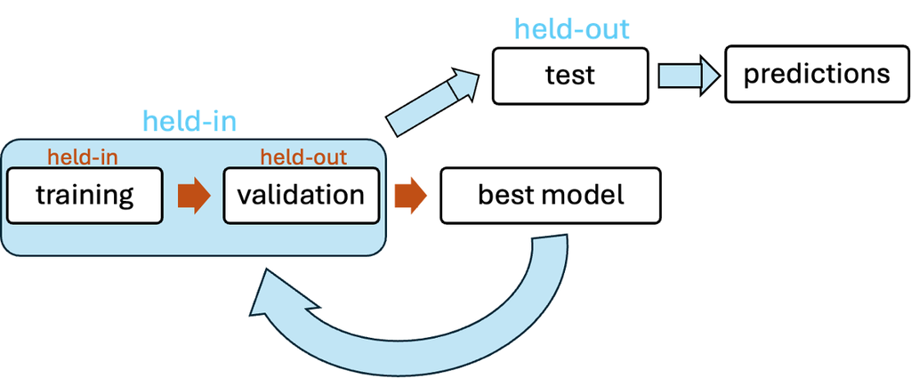

We prep the best recipe to the held-in set (training & validation combined), and bake it to both held-in and held-out (test data) sets. We then train the best model configuration using these held-in features and generate predictions using the held-out features.

## 8. How do we handle categorical predictors?

> *Q: How can you deal with the variables like name or cabin from the homework?*

If the variable is nominal (qualitative categories, no inherent order), we can do dummy coding, contrast coding, etc.

If the variable is ordinal (inherent order but not equidistant spacing), we can either do 1) dummy coding, contrast coding, etc, like above, or 2) treat them as ordered levels. You can choose between those two methods by treating these as different model configurations and comparing them using held-out (validation) data.